# tidysynthesis and syntheval demos

Author

Affiliation

Aaron R. Williams and Jeremy Seeman

Urban Institute

Abstract

This hands-on demonstration introduces the tidysynthesis and syntheval R packages for generating and evaluating synthetic data. During the course of the demo, we will generate and evaluate three synthetic versions of ACS microdata. The first synthesis will rely on defaults in tidysynthesis. The second and third syntheses increase the amount of noise in the synthetic data to increase privacy protections.

## Setup

We start by loading necessary R packages.

```r
library(tidymodels)
library(tidysynthesis)
library(syntheval)

# turn off scientific notation
options(scipen = 999)
```

We set the seed to make the entire process, which is random, reproducible.

```r
set.seed(1)
```

## “Confidential Data”

Our demo will use an extract constructed from the 2019 American Community Survey containing a survey sample of n = 1,500 Nebraska respondents.

The file contains seven categorical variables and four numeric variables. Some of the variables contain `NA`.

```r
glimpse(acs_conf_nw)
```

```
Rows: 1,500
Columns: 11
$ county       <fct> Other, Other, Other, Other, Douglas, Lancaster, Other, Sa…
$ gq           <fct> Household, Household, Household, Household, Household, Ho…
$ sex          <fct> Female, Male, Male, Female, Male, Female, Male, Male, Mal…
$ marst        <fct> Single, Married, Single, Single, Married, Divorced, Marri…
$ hcovany      <fct> With health insurance coverage, With health insurance cov…
$ empstat      <fct> NA, Employed, NA, NA, Employed, Employed, NA, NA, NA, Emp…
$ classwkr     <fct> N/A, Works for wages, N/A, N/A, Self-employed, Works for …
$ age          <dbl> 0, 41, 10, 12, 46, 36, 49, 5, 22, 31, 5, 55, 74, 50, 37, …
$ famsize      <dbl> 5, 4, 3, 6, 5, 3, 5, 5, 4, 1, 4, 2, 2, 2, 4, 1, 1, 4, 5, …
$ transit_time <dbl> 0, 30, 0, 0, 15, 15, 0, 0, 0, 5, 0, 7, 0, 15, 10, 0, 0, 0…
$ inctot       <dbl> NA, 68000, NA, NA, 91000, 26200, 6000, NA, 0, 37000, NA, …
```

## `roadmap`

**roadmap**

A `roadmap` object contains information about the order of operations for a specific synthesis, which is required for all syntheses. You can create a roadmap S3 object using the function `roadmap()` that requires two arguments:

- `conf_data`: A data frame with the confidential data used to generate the synthetic data. The resulting synthetic data will have the same number of columns as `conf_data`.
- `start_data`: A data frame with a strict subset of variables from `conf_data`, which is used to start the synthesis process. The resulting synthetic data will have the same number of rows as `start_data`.

```r
acs_start <- acs_conf_nw |>
  select(county) |>
  slice_sample(n = 1500)

acs_roadmap1 <- roadmap(
  conf_data = acs_conf_nw,
  start_data = acs_start
)
```

`roadmap()` creates defaults for the schema, visit sequence, replicates, and constraints. We will use the defaults (for now).

The `schema` object learns the types from the confidential data.

```r
acs_roadmap1[["schema"]]
```

```
Schema: 11 columns
fct fct fct fct fct fct fct dbl dbl dbl dbl
```

The visit sequence uses the variable order in the data excluding the variables in `start_data`.

```r
acs_roadmap1[["visit_sequence"]]
```

```
Visit Sequence
Method:Variable
default:gq default:sex default:marst default:hcovany default:empstat default:classwkr default:age default:famsize default:transit_time default:inctot
```

The number of replicates defaults to 1.

```r
acs_roadmap1[["replicates"]]
```

```
Replicates

Start Data Replicates:  1
Model Sample Replicates:  1
End-to-End Replicates:  1

Total Replicates:  1
```

The synthesis doesn’t use any constraints.

```r
acs_roadmap1[["constraints"]]
```

```
Constraints specified per variable:
age: 0
famsize: 0
transit_time: 0
inctot: 0
```

**Takeaway**

This default `roadmap` selects the variables we will synthesize and the order we will use to synthesize the data.

## `synth_spec`

**synth_spec**

A `synth_spec` object specifies the modeling and sampling components used for sequential synthetic data generation. The `synth_spec()` function creates a `synth_spec` S3 object and contains many arguments for changing the `synth_spec.` But each `synth_spec` requires that every synthesized variable be associated with a model object and a sampler function.

The `synth_spec` provides you flexibility to arbitrarily specify the details of different models, samplers, and more.

- `default_regression_model`: The default predictive model used to generate numeric data.
- `default_classification_model`: The default predictive model used to generate categorical data.
- `default_regression_sampler`: The default sampling method used to sample from regression models.
- `default_classification_sampler`: The default sampling method used to sample from classification models.
- `default_regression_noise`: The (optional) default noise mechanism for regression models.
- `default_classification_noise`: The (optional) default noise mechanism for classification models.

We will use regression trees and decision trees to model all of our variables. These tree-based models easily handle non-linear patterns and interactions in data. They are also easy to sample from, which we will do using the built-in `sample_rpart()` function.[^1]

```r
rpart_reg <- decision_tree() |>
  set_engine(engine = "rpart") |>
  set_mode(mode = "regression")

rpart_class <- decision_tree() |>
  set_engine(engine = "rpart") |>
  set_mode(mode = "classification")
```

We can combine our models and samplers into one `synth_spec` object. We set defaults for categorical and numeric variables. If needed, we have robust options for matching different models and samplers to specific variables in the visit sequence.

```r
# create a basic synth_spec
acs_synth_spec1 <- synth_spec(
  # use previously defined parsnip models
  default_regression_model = rpart_reg,
  default_classification_model = rpart_class,
  # use tidysynthesis-provided sampler functions
  default_regression_sampler = sample_rpart,
  default_classification_sampler = sample_rpart
)
```

**Takeaway**

## `synthesize`

We can combine the `roadmap` and `synth_spec` into a `presynth` object and generate synthetic data. Note: no serious computation happens until `synthesize()`.

```r
acs_presynth1 <- presynth(
  roadmap = acs_roadmap1,
  synth_spec = acs_synth_spec1
)
```

```
Some variable(s) have no non-default visit sequence method specified: TRUE, TRUE, TRUE, TRUE, TRUE, TRUE, TRUE, TRUE, TRUE, TRUE, TRUE
```

```r
acs_synth1 <- synthesize(acs_presynth1)
```

```
Synthesizing 1/11 gq ...
```

```
Synthesizing 2/11 sex ...
```

```
Synthesizing 3/11 marst ...
```

```
Synthesizing 4/11 hcovany ...
```

```
Synthesizing 5/11 empstat ...
```

```
Synthesizing 6/11 classwkr ...
```

```
Synthesizing 7/11 age ...
```

```
Synthesizing 8/11 famsize ...
```

```
Synthesizing 9/11 transit_time ...
```

```
Synthesizing 10/11 inctot_NA ...
```

```
Synthesizing 11/11 inctot ...
```

We can look at the synthetic data.

```r
glimpse(acs_synth1[["synthetic_data"]])
```

```
Rows: 1,500
Columns: 12
$ county       <fct> Sarpy, Other, Douglas, Other, Lancaster, Other, Other, Do…
$ gq           <fct> Household, Household, Household, Other GQ, Household, Hou…
$ sex          <fct> Male, Male, Female, Female, Female, Female, Female, Male,…
$ marst        <fct> Widowed, Single, Single, Single, Divorced, Married, Marri…
$ hcovany      <fct> With health insurance coverage, With health insurance cov…
$ empstat      <fct> NA, NA, NA, Employed, Employed, Employed, NA, NA, NA, NA,…
$ classwkr     <fct> N/A, Self-employed, N/A, Works for wages, Works for wages…
$ age          <dbl> 71, 44, 9, 24, 62, 44, 69, 6, 40, 10, 57, 12, 78, 34, 87,…
$ famsize      <dbl> 2, 5, 2, 1, 1, 3, 2, 3, 5, 5, 2, 5, 1, 1, 2, 7, 2, 6, 2, …
$ transit_time <dbl> 0, 0, 0, 30, 5, 3, 0, 0, 0, 0, 0, 0, 0, 133, 0, 0, 0, 15,…
$ inctot_NA    <fct> nonmissing value, nonmissing value, missing value, nonmis…
$ inctot       <dbl> 30400, 21000, NA, 12000, 26000, 140000, 11900, NA, 0, NA,…
```

Finally, we do a little housekeeping to clean up our `NA` values.

```r
acs_eval1 <- acs_synth1[["synthetic_data"]] |>
  collapse_na() |>
  convert_level_to_na()
```

## Evaluate

`library(syntheval)` contains a suite of functions for evaluating the quality of our synthetic data.

We will focus on the categorical variable `empstat` and the numeric variable `inctot`.

```r
util_proportions(postsynth = acs_eval1, data = acs_conf_nw) |>
  filter(variable == "empstat")
```

```
# A tibble: 3 × 5
  variable class      synthetic original difference
  <chr>    <fct>          <dbl>    <dbl>      <dbl>
1 empstat  Employed      0.519    0.503     0.0153
2 empstat  Unemployed    0.0133   0.0147   -0.00133
3 empstat  NA            0.468    0.482    -0.0140
```

```r
util_moments(postsynth = acs_eval1, data = acs_conf_nw, na.rm = TRUE) |>
  filter(variable == "inctot")
```

```
# A tibble: 5 × 6
  variable statistic original synthetic difference proportion_difference
  <fct>    <fct>        <dbl>     <dbl>      <dbl>                 <dbl>
1 inctot   count      1155      1195        40                    0.0346
2 inctot   mean      40944.    40504.     -440.                  -0.0107
3 inctot   sd        51651.    57681.     6029.                   0.117
4 inctot   skewness      5.18      5.79      0.603                0.116
5 inctot   kurtosis     46.8      50.8       4.05                 0.0867
```

```r
util_percentiles(postsynth = acs_eval1, data = acs_conf_nw, na.rm = TRUE) |>
  filter(variable == "inctot")
```

```
# A tibble: 3 × 6
      p variable original synthetic difference proportion_difference
  <dbl> <fct>       <dbl>     <dbl>      <dbl>                 <dbl>
1   0.1 inctot       1200      270.       -930               -0.775
2   0.5 inctot      30000    28000       -2000               -0.0667
3   0.9 inctot      84000    78000       -6000               -0.0714
```

We can also look at multivariate utility metrics. We can look at correlation matrices.

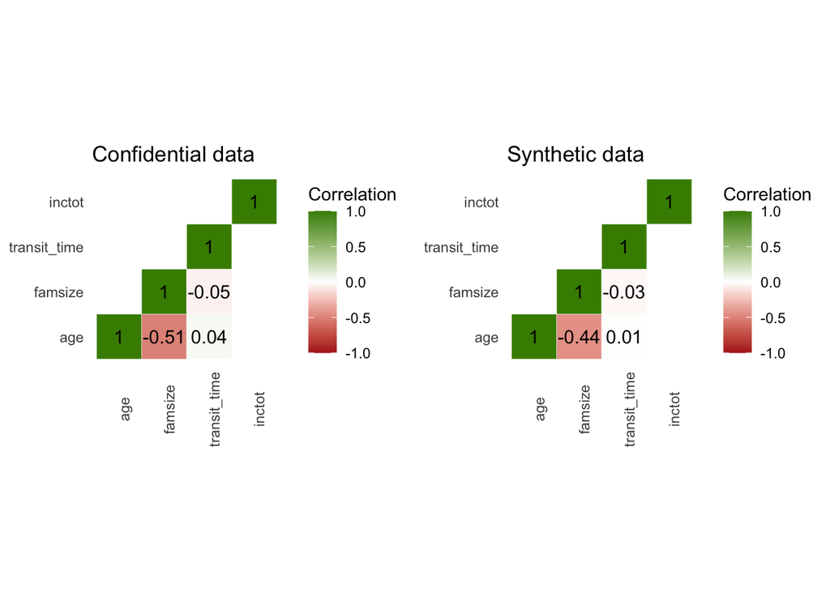

```r
plot_cormat(synth_data = acs_eval1, conf_data = acs_conf_nw)
```

We can compare linear regression models fit on both data sets.

```r
ci_overlap <- util_ci_overlap(postsynth = acs_eval1, data = acs_conf_nw, formula = inctot ~ age)

ci_overlap
```

```
$ci_overlap
# A tibble: 2 × 8
  term    overlap coef_diff std_coef_diff sign_match significance_match ss_match
  <chr>     <dbl>     <dbl>         <dbl> <lgl>      <lgl>              <lgl>
1 (Inter…   0.903    1523.          0.402 TRUE       TRUE               TRUE
2 age       0.859     -40.8        -0.578 TRUE       TRUE               TRUE
# ℹ 1 more variable: sso_match <lgl>

$coefficient
# A tibble: 4 × 8
  source    term        estimate std.error statistic  p.value conf.low conf.high
  <chr>     <chr>          <dbl>     <dbl>     <dbl>    <dbl>    <dbl>     <dbl>
1 original  (Intercept)   25882.    3785.       6.84 1.26e-11   18456.    33308.
2 original  age             304.      70.6      4.31 1.76e- 5     166.      443.
3 synthetic (Intercept)   27405.    4090.       6.70 3.08e-11   19381.    35429.
4 synthetic age             264.      75.9      3.47 5.30e- 4     115.      412.
```

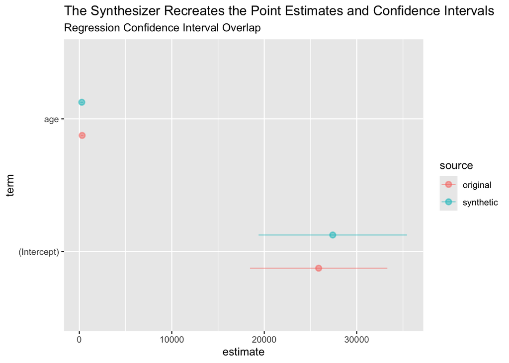

```r
ci_overlap$coefficient |>
  ggplot(aes(x = estimate, xmin = conf.low, xmax = conf.high, y = term, color = source)) +
  geom_pointrange(alpha = 0.5, position = position_dodge(width = 0.5)) +
  labs(
    title = "The Synthesizer Recreates the Point Estimates and Confidence Intervals",
    subtitle = "Regression Confidence Interval Overlap"
  )
```

**Takeaway**

We created a simple `roadmap` and a simple `synth_spec`. We combined both object into a `presynth` and generated a synthetic data set.

## Approach 2

Let’s build a new synthesis that:

1. Uses a custom visit sequence.
2. Adds logical constraints that must hold in the synthetic data.
3. Adds additional noise to the synthetic data.

### Visit Sequence

We create a new visit sequence that orders categorical variables from highest to lowest entropy and numeric variables from most to least correlated with the variable `age`.

We’ll start with `acs_roadmap1` and update it to create `acs_roadmap2`.

```r
acs_roadmap2 <- acs_roadmap1 |>
  add_sequence_factor(where(is.factor), method = "entropy") |>
  add_sequence_numeric(where(is.numeric), method = "correlation", cor_var = "age", na.rm = TRUE)

acs_roadmap2[["visit_sequence"]]
```

```
Visit Sequence
Method:Variable
entropy:empstat entropy:hcovany entropy:gq entropy:sex entropy:classwkr entropy:marst correlation:age correlation:famsize correlation:transit_time correlation:inctot
```

### Constraints

We add an unconditional non-negativity constraint for `age` and a conditional constraint for `inctot`. We can add as many numeric constraints as we want with minima, maxima, and conditions by creating a data frame. We then add these constraints to the `roadmap`.

```r
ex_acs_constraints_numeric <- tibble::tribble(
  # required column names
  ~var, ~min, ~max, ~conditions,
  # 'age' is always positive
  "age", 0, Inf, "TRUE",
  # 'inctot' is always < 12000 whenever age <= 18
  "inctot", 0, 12000, "age <= 18"
)

ex_acs_constraints_numeric
```

```
# A tibble: 2 × 4
  var      min   max conditions
  <chr>  <dbl> <dbl> <chr>
1 age        0   Inf TRUE
2 inctot     0 12000 age <= 18
```

```r
acs_roadmap2 <- acs_roadmap2 |>
  add_constraints(
    constraints = constraints(acs_roadmap2[["schema"]], ex_acs_constraints_numeric)
  )
```

### Noise

To increase privacy protection, we add extra noise to the synthesis process using a uniform distribution for classification models and a Gaussian distribution for numeric variables.

```r
noise_mechanism_class2 <- noise(
  add_noise = TRUE,
  mode = "classification",
  noise_func = add_noise_cat_unif,
  unif_prop = 0.1
)

noise_mechanism_reg2 <- noise(
  add_noise = TRUE,
  mode = "regression",
  noise_func = add_noise_gaussian,
  variance = 100 ^ 2
)
```

We create a new `synth_spec` object with the noise functions.

```r
# create a basic synth_spec
acs_synth_spec2 <- synth_spec(
  # use previously defined parsnip models
  default_regression_model = rpart_reg,
  default_classification_model = rpart_class,
  # use tidysynthesis-provided sampler functions
  default_regression_sampler = sample_rpart,
  default_classification_sampler = sample_rpart,
  # use defined noise functions
  default_regression_noise = noise_mechanism_reg2,
  default_classification_noise = noise_mechanism_class2
)
```

Next, we create our second synthetic data set.

```r
acs_presynth2 <- presynth(
  roadmap = acs_roadmap2,
  synth_spec = acs_synth_spec2
)
acs_synth2 <- synthesize(acs_presynth2)
```

```
Synthesizing 1/11 empstat ...
```

```
Synthesizing 2/11 hcovany ...
```

```
Synthesizing 3/11 gq ...
```

```
Synthesizing 4/11 sex ...
```

```
Synthesizing 5/11 classwkr ...
```

```
Synthesizing 6/11 marst ...
```

```
Synthesizing 7/11 age ...
```

```
Synthesizing 8/11 famsize ...
```

```
Synthesizing 9/11 transit_time ...
```

```
Synthesizing 10/11 inctot_NA ...
```

```
Synthesizing 11/11 inctot ...
```

We can look at the synthetic data.

```r
glimpse(acs_synth2[["synthetic_data"]])
```

```
Rows: 1,500
Columns: 12
$ county       <fct> Sarpy, Other, Douglas, Other, Lancaster, Other, Other, Do…
$ empstat      <fct> Employed, Employed, Employed, NA, NA, Employed, Employed,…
$ hcovany      <fct> With health insurance coverage, With health insurance cov…
$ gq           <fct> Household, Household, Household, Household, Household, Ho…
$ sex          <fct> Male, Female, Female, Male, Male, Female, Male, Male, Fem…
$ classwkr     <fct> Works for wages, Self-employed, Self-employed, Works for …
$ marst        <fct> Single, Married, Single, Single, Married, Married, Widowe…
$ age          <dbl> 164.260472, 4.554510, 49.825550, 61.636729, 161.916524, 2…
$ famsize      <dbl> -65.05420, 11.95845, -16.84855, -203.28572, -195.14689, 1…
$ transit_time <dbl> -103.248472, 130.091675, 70.461926, 137.028211, -69.47091…
$ inctot_NA    <fct> nonmissing value, missing value, nonmissing value, nonmis…
$ inctot       <dbl> 14993.68, NA, 81197.64, 42011.37, 30430.34, 33222.23, 120…
```

Finally, we clean up our `NA` values.

```r
acs_eval2 <- acs_synth2[["synthetic_data"]] |>
  collapse_na()
```

**Takeaway**

We generated a second synthesis. This synthesis uses a data-informed visit sequence, implemented two constraints, and added additional noise to model-generated values.

## Approach 3

For our third synthesis, we use the same noise mechanism as our second synthesis, but increase the `unif_prop` and `variance` parameters to increase the amount of noise in the synthetic data.

```r
noise_mechanism_class3 <- noise(
  add_noise = TRUE,
  mode = "classification",
  noise_func = add_noise_cat_unif,
  unif_prop = 0.5
)

noise_mechanism_reg3 <- noise(
  add_noise = TRUE,
  mode = "regression",
  noise_func = add_noise_gaussian,
  variance = 100000 ^ 2
)
```

We create one more `synth_spec` object.

```r
# create a basic synth_spec
acs_synth_spec3 <- synth_spec(
  # use previously defined parsnip models
  default_regression_model = rpart_reg,
  default_classification_model = rpart_class,
  # use tidysynthesis-provided sampler functions
  default_regression_sampler = sample_rpart,
  default_classification_sampler = sample_rpart,
  # use defined noise functions
  default_regression_noise = noise_mechanism_reg3,
  default_classification_noise = noise_mechanism_class3
)
```

Next, we create our third synthetic data set.

```r
acs_presynth3 <- presynth(
  roadmap = acs_roadmap2,
  synth_spec = acs_synth_spec3
)
acs_synth3 <- synthesize(acs_presynth3)
```

```
Synthesizing 1/11 empstat ...
```

```
Synthesizing 2/11 hcovany ...
```

```
Synthesizing 3/11 gq ...
```

```
Synthesizing 4/11 sex ...
```

```
Synthesizing 5/11 classwkr ...
```

```
Synthesizing 6/11 marst ...
```

```
Synthesizing 7/11 age ...
```

```
Synthesizing 8/11 famsize ...
```

```
Synthesizing 9/11 transit_time ...
```

```
Synthesizing 10/11 inctot_NA ...
```

```
Synthesizing 11/11 inctot ...
```

We can look at the synthetic data.

```r
glimpse(acs_synth3[["synthetic_data"]])
```

```
Rows: 1,500
Columns: 12
$ county       <fct> Sarpy, Other, Douglas, Other, Lancaster, Other, Other, Do…
$ empstat      <fct> Employed, Employed, Employed, Employed, Employed, Unemplo…
$ hcovany      <fct> With health insurance coverage, No health insurance cover…
$ gq           <fct> Household, Household, Other GQ, Household, Household, Ins…
$ sex          <fct> Male, Male, Male, Female, Male, Male, Female, Female, Mal…
$ classwkr     <fct> Works for wages, N/A, Works for wages, Works for wages, N…
$ marst        <fct> Single, Married, Single, Separated, Single, Separated, Wi…
$ age          <dbl> 0.00, 0.00, 0.00, 0.00, 0.00, 218411.22, 0.00, 0.00, 0.00…
$ famsize      <dbl> 18064.143, -34854.586, 315664.091, 75189.661, 169302.346,…
$ transit_time <dbl> -80949.154, 21969.678, -135665.530, 56253.815, 138069.702…
$ inctot_NA    <fct> nonmissing value, missing value, nonmissing value, missin…
$ inctot       <dbl> 12000.00, NA, 12000.00, NA, NA, 181332.76, NA, NA, 12000.…
```

Finally, we clean up the `NA` values.

```r
acs_eval3 <- acs_synth3[["synthetic_data"]] |>
  collapse_na()
```

## Final Evaluation

Let’s compare the distribution of `empstat` in the confidential data and the three synthetic files. As `unif_prop` increases, the synthetic data are less informed by the confidential data. This is one approach to increase privacy protections at the expense of data quality.

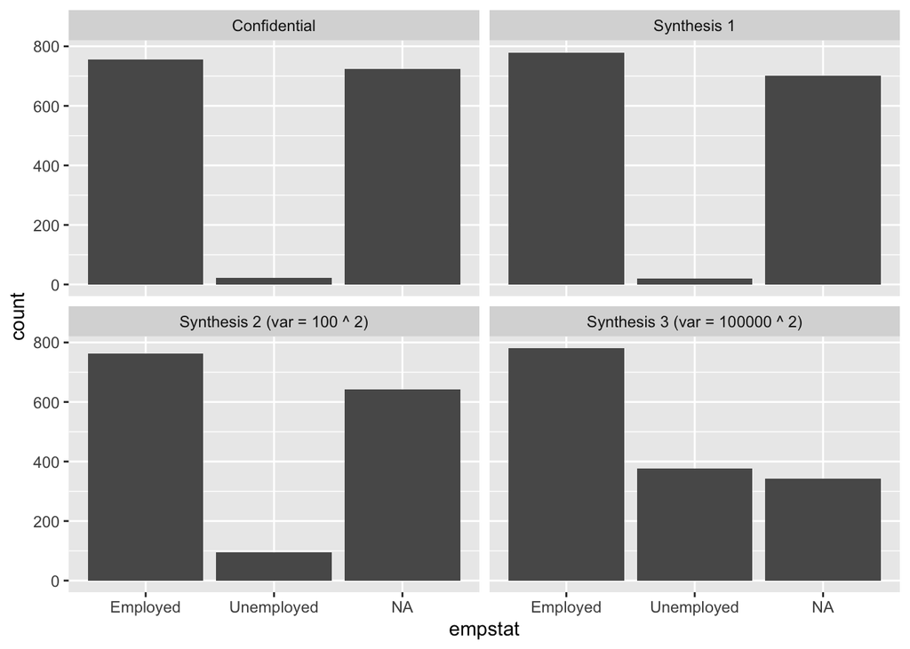

```r
bind_rows(
  `Confidential` = acs_conf_nw,
  `Synthesis 1` = acs_eval1,
  `Synthesis 2 (var = 100 ^ 2)` = acs_eval2,
  `Synthesis 3 (var = 100000 ^ 2)` = acs_eval3,
  .id = "Source"
) |>
  ggplot(aes(empstat)) +
  geom_bar() +
  facet_wrap(~ Source)
```

Let’s compare the distribution of `inctot` in the confidential data and the three synthetic files. As `vaiance` increases, the synthetic data are less informed by the confidential data.

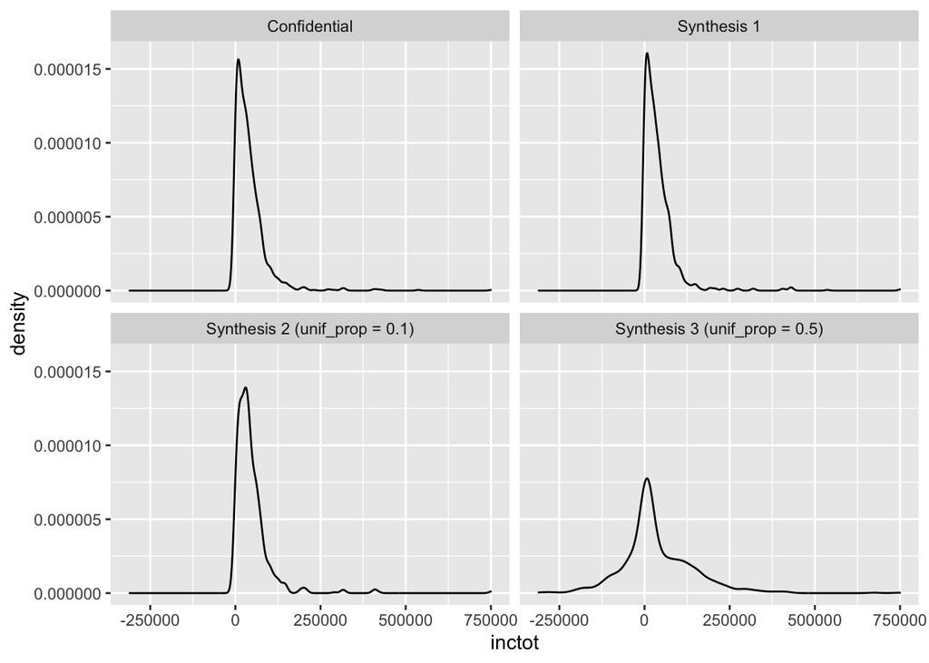

```r
bind_rows(
  `Confidential` = acs_conf_nw,
  `Synthesis 1` = acs_eval1,
  `Synthesis 2 (unif_prop = 0.1)` = acs_eval2,
  `Synthesis 3 (unif_prop = 0.5)` = acs_eval3,
  .id = "Source"
) |>
  ggplot(aes(inctot)) +
  geom_density() +
  facet_wrap(~ Source)
```

**Note**

We generated three synthetic data sets. With each data set, we increased the amount of noise added to model-generated values. This extra noise increased privacy (not demonstrated) but reduced the data quality by reducing how much the synthesizer could learn from the confidential data.

## Footnotes

[^1]: R2D3 has a visual explanation of decision trees: http://www.r2d3.us/visual-intro-to-machine-learning-part-1/